# Assignment 3A: Global Baseline Estimate — Approach & Code Base

DATA 607 · Week 3

Author

Dillon Leeper

## Overview

Most recommender systems rely on personalized algorithms such as content-based filtering or item-item collaborative filtering. The **Global Baseline Estimate** is a useful, simpler alternative: a non-personalized recommender that predicts a rating using only the overall rating distribution, how a given item tends to be rated relative to everyone else, and how a given user tends to rate relative to everyone else. It serves as a benchmark that any personalized algorithm should be expected to beat.

This document implements a Global Baseline Estimate recommender in R using the movie ratings survey data collected for Assignment 2A — the same 7-respondent, 6-movie dataset stored in PostgreSQL and documented in `week02_2a_approach.qmd`.

## The Algorithm

For a user $u$ and item (movie) $i$, the baseline prediction is:

$$\text{baseline}(u, i) = \mu + b_u + b_i$$

where:

- $\mu$ — the overall average across all users and all movies
- $b_i$ — the item bias: how much movie $i$’s average rating deviates from $\mu$
- $b_u$ — the user bias: how much user $u$’s ratings deviate from $\mu$, after accounting for the items they rated

The result is typically clipped to the valid rating scale, since $\mu + b_u + b_i$ can fall outside the original bounds.

## Planned Approach

### 1. Organize the Data

Import the survey data and reshape it from wide format (one row per respondent, one column per movie) into long/tidy format with `tidyr::pivot_longer()`, so each row represents a single (user, movie, rating) observation. Missing/unrated cells will be filtered out rather than treated as zero ratings.

### 2. Compute the Global Mean

Calculate $\mu$ as the mean of every recorded rating in the long-format data frame, ignoring missing values.

### 3. Compute Item (Movie) Bias

For each movie, compute:

$$b_i = \overline{\text{rating}_i} - \mu$$

grouping by movie and averaging its ratings, then subtracting the global mean.

### 4. Compute User Bias

For each user, correct for item bias before averaging: subtract both $\mu$ and the relevant movie’s $b_i$ from each of that user’s ratings, then average the residuals:

$$b_u = \text{mean}(\text{rating}_{u,i} - \mu - b_i)$$

### 5. Compute Baseline Predictions

Combine $\mu$, $b_u$, and $b_i$ for every (user, movie) pair — including pairs the user has not yet rated — to produce a predicted rating, clipped to the valid scale (1–5).

### 6. Generate Recommendations

For each user, rank the movies they have not yet rated by predicted baseline score and surface the top-ranked titles as recommendations.

## R Implementation

```r
library(tidyverse)
```

### Dataset

This reproduces the exact 7-respondent × 6-movie survey table from Assignment 2A (`week02_2a_approach.qmd`), where `NA` marks “haven’t seen it” / unanswered cells — never a 0 rating.

```r
ratings_wide <- tribble(
  ~user,          ~`Everything Everywhere All at Once`, ~`The Batman`, ~Hereditary, ~Obsession, ~`The Odyssey`, ~`Mean Girls`,
  "Eduardo",       4,  3, NA, NA,  5, NA,
  "Annie",         4,  3, NA, NA, NA,  5,
  "James",         2,  2, NA, NA,  4,  3,
  "JOYEEEEEEEE",  NA, NA, NA,  5,  4, NA,
  "Chris",         5, NA,  3,  5, NA,  5,
  "Garrett",      NA,  4, NA, NA,  4,  3,
  "Robyn",         1, NA, NA, NA,  4,  4
)

# To pull live from the Assignment 2A PostgreSQL database instead
# (same connection pattern as week02_2a_approach.qmd):
# library(DBI); library(RPostgres)
# con <- dbConnect(RPostgres::Postgres(),
#   host = Sys.getenv("PGHOST", "localhost"), port = as.integer(Sys.getenv("PGPORT", "5432")),
#   dbname = Sys.getenv("PGDATABASE", "movie_ratings"), user = Sys.getenv("PGUSER", "postgres"),
#   password = Sys.getenv("PGPASSWORD"))
# ratings_long <- dbGetQuery(con, "SELECT u.name AS user, m.title AS movie, r.rating
#                             FROM ratings r JOIN users u ON r.user_id = u.user_id
#                             JOIN movies m ON r.movie_id = m.movie_id") |> filter(!is.na(rating))
# dbDisconnect(con)

ratings_wide
```

| user | Everything Everywhere All at Once | The Batman | Hereditary | Obsession | The Odyssey | Mean Girls |
| --- | --- | --- | --- | --- | --- | --- |
| Eduardo | 4 | 3 | NA | NA | 5 | NA |
| Annie | 4 | 3 | NA | NA | NA | 5 |
| James | 2 | 2 | NA | NA | 4 | 3 |
| JOYEEEEEEEE | NA | NA | NA | 5 | 4 | NA |
| Chris | 5 | NA | 3 | 5 | NA | 5 |
| Garrett | NA | 4 | NA | NA | 4 | 3 |
| Robyn | 1 | NA | NA | NA | 4 | 4 |

### Reshape to Long Format

```r
ratings_long <- ratings_wide |>
  pivot_longer(-user, names_to = "movie", values_to = "rating") |>
  filter(!is.na(rating))

ratings_long
```

| user | movie | rating |
| --- | --- | --- |
| Eduardo | Everything Everywhere All at Once | 4 |
| Eduardo | The Batman | 3 |
| Eduardo | The Odyssey | 5 |
| Annie | Everything Everywhere All at Once | 4 |
| Annie | The Batman | 3 |
| Annie | Mean Girls | 5 |
| James | Everything Everywhere All at Once | 2 |
| James | The Batman | 2 |
| James | The Odyssey | 4 |
| James | Mean Girls | 3 |

[output cut: 12 more lines]

### Global Mean

```r
mu <- mean(ratings_long$rating)
mu
```

```
[1] 3.727273
```

### Item Bias

```r
item_bias <- ratings_long |>
  group_by(movie) |>
  summarize(b_i = mean(rating) - mu, n_ratings = n(), .groups = "drop")

item_bias
```

| movie | b_i | n_ratings |
| --- | --- | --- |
| Everything Everywhere All at Once | -0.5272727 | 5 |
| Hereditary | -0.7272727 | 1 |
| Mean Girls | 0.2727273 | 5 |
| Obsession | 1.2727273 | 2 |
| The Batman | -0.7272727 | 4 |
| The Odyssey | 0.4727273 | 5 |

### User Bias

```r
user_bias <- ratings_long |>
  left_join(item_bias, by = "movie") |>
  group_by(user) |>
  summarize(b_u = mean(rating - mu - b_i), n_ratings = n(), .groups = "drop")

user_bias
```

| user | b_u | n_ratings |
| --- | --- | --- |
| Annie | 0.60000000 | 3 |
| Chris | 0.70000000 | 4 |
| Eduardo | 0.53333333 | 3 |
| Garrett | -0.06666667 | 3 |
| JOYEEEEEEEE | -0.10000000 | 2 |
| James | -0.85000000 | 4 |
| Robyn | -0.80000000 | 3 |

### Baseline Predictions

Predictions for every (user, movie) pair, clipped to the 1–5 scale, joined back against the actual rating where one exists.

```r
baseline_predictions <- expand_grid(
  user  = unique(ratings_long$user),
  movie = unique(ratings_long$movie)
) |>
  left_join(user_bias |> select(user, b_u), by = "user") |>
  left_join(item_bias |> select(movie, b_i), by = "movie") |>
  mutate(
    predicted_rating = pmin(pmax(mu + b_u + b_i, 1), 5)
  ) |>
  left_join(ratings_long, by = c("user", "movie")) |>
  rename(actual_rating = rating)

baseline_predictions
```

| user | movie | b_u | b_i | predicted_rating | actual_rating |
| --- | --- | --- | --- | --- | --- |
| Eduardo | Everything Everywhere All at Once | 0.53333333 | -0.5272727 | 3.733333 | 4 |
| Eduardo | The Batman | 0.53333333 | -0.7272727 | 3.533333 | 3 |
| Eduardo | The Odyssey | 0.53333333 | 0.4727273 | 4.733333 | 5 |
| Eduardo | Mean Girls | 0.53333333 | 0.2727273 | 4.533333 | NA |
| Eduardo | Obsession | 0.53333333 | 1.2727273 | 5.000000 | NA |
| Eduardo | Hereditary | 0.53333333 | -0.7272727 | 3.533333 | NA |
| Annie | Everything Everywhere All at Once | 0.60000000 | -0.5272727 | 3.800000 | 4 |
| Annie | The Batman | 0.60000000 | -0.7272727 | 3.600000 | 3 |
| Annie | The Odyssey | 0.60000000 | 0.4727273 | 4.800000 | NA |
| Annie | Mean Girls | 0.60000000 | 0.2727273 | 4.600000 | 5 |

[output cut: 32 more lines]

## Validation

### Fit Against Known Ratings

We evaluate model accuracy on observed data using Root Mean Squared Error (RMSE).

```r
# --- 1. Filter Down to Known Ratings ---
known_ratings <- baseline_predictions |>
  filter(!is.na(actual_rating))

# --- 2. Calculate Root Mean Squared Error (RMSE) ---
rmse <- sqrt(mean((known_ratings$predicted_rating - known_ratings$actual_rating)^2))

# Display the RMSE value
rmse
```

```
[1] 0.6169328
```

```r
# --- 3. Interpretation & Scale Context ---
# On a 1 to 5 rating scale:
# - 0.0 represents perfect prediction (zero error)
# - 4.0 represents the maximum possible error
# An RMSE of ~0.62 means our predictions are off by an average of roughly 0.6 stars.
```

### Manual Spot Check

To ensure our automated data pipeline is reliable, we perform a manual spot check on a single prediction (Eduardo’s score for *Mean Girls*).

By calculating this prediction directly using basic arithmetic and comparing it to the output generated through our multi-step `left_join()` pipeline, we verify two critical things:

1. **Mathematical Accuracy:** The join logic executes the formula ($\mu + b_u + b_i$) exactly as intended.
2. **Data Integrity:** The automated pipeline has not scrambled user profiles or movie attributes during processing.

```r
manual_pred <- pmin(pmax(
  mu +
    user_bias$b_u[user_bias$user == "Eduardo"] +
    item_bias$b_i[item_bias$movie == "Mean Girls"],
  1), 5)

computed_pred <- baseline_predictions |>
  filter(user == "Eduardo", movie == "Mean Girls") |>
  pull(predicted_rating)

tibble(manual_pred, computed_pred, match = isTRUE(all.equal(manual_pred, computed_pred)))
```

| manual_pred | computed_pred | match |
| --- | --- | --- |
| 4.533333 | 4.533333 | TRUE |

## Recommendations

For each respondent, the top-ranked movies they haven’t rated, by predicted baseline score.

```r
recommendations <- baseline_predictions |>
  filter(is.na(actual_rating)) |>
  group_by(user) |>
  arrange(desc(predicted_rating), .by_group = TRUE) |>
  slice_head(n = 3) |>
  select(user, movie, predicted_rating) |>
  ungroup()

recommendations
```

| user | movie | predicted_rating |
| --- | --- | --- |
| Annie | Obsession | 5.000000 |
| Annie | The Odyssey | 4.800000 |
| Annie | Hereditary | 3.600000 |
| Chris | The Odyssey | 4.900000 |
| Chris | The Batman | 3.700000 |
| Eduardo | Obsession | 5.000000 |
| Eduardo | Mean Girls | 4.533333 |
| Eduardo | Hereditary | 3.533333 |
| Garrett | Obsession | 4.933333 |
| Garrett | Everything Everywhere All at Once | 3.133333 |

[output cut: 9 more lines]

## Visualization

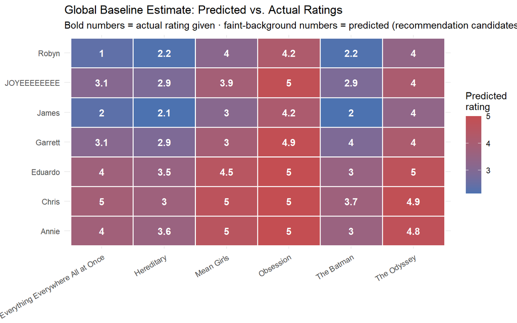

Figure 1

```r
baseline_predictions |>
  mutate(known = !is.na(actual_rating)) |>
  ggplot(aes(x = movie, y = user, fill = predicted_rating)) +
  geom_tile(color = "white", linewidth = 0.6) +
  geom_text(aes(label = ifelse(known, as.character(actual_rating), round(predicted_rating, 1))),
            color = "white", fontface = "bold") +
  scale_fill_gradient(low = "#4C72B0", high = "#C44E52", name = "Predicted\nrating") +
  labs(
    title = "Global Baseline Estimate: Predicted vs. Actual Ratings",
    subtitle = "Bold numbers = actual rating given · faint-background numbers = predicted (recommendation candidates)",
    x = NULL, y = NULL
  ) +
  theme_minimal() +
  theme(axis.text.x = element_text(angle = 30, hjust = 1))
```

## Conclusions

The Global Baseline Estimate guesses how someone would rate a movie they haven’t seen using just three numbers: the overall average rating, how generous or harsh that person tends to rate, and how well-liked that movie is overall. It’s a simple baseline, and any fancier recommender should be able to beat it.

**Findings:** On the 22 ratings we actually collected, predictions were off by about 0.6 stars on average (RMSE ≈ 0.62) on a 1–5 scale. That’s a believable guess, but it’s a low bar since we’re checking accuracy on the same ratings the model was built from. The recommendations table matches intuition pretty well too: people who rated things generously, like Chris, get more optimistic predictions across the board, while stingier raters, like Robyn, get lower ones.

**Limitations:** We only had 7 respondents and 6 movies, and only 22 of the 42 possible (user, movie) pairs actually got rated. That means both the user bias and movie bias numbers come from very little data. One rating from a single person, or for a single movie, can swing that bias a lot, so the biases (and the recommendations built from them) shouldn’t be trusted as much as they would with a bigger survey.

**Ideas to extend or verify this work:**

- Collect more responses per movie and more ratings per person so the bias estimates aren’t so shaky.
- Hold out a chunk of the real ratings and predict against that instead of checking accuracy on the same data the model trained on. That gives a more honest read on predictive accuracy.
- Compare this baseline against something a bit smarter, like item-item collaborative filtering, to actually confirm it gets beaten. That’s the whole point of having a baseline in the first place.

## AI Disclosure and Citation

Claude (Sonnet 5, accessed through Claude for Cowork) reviewed this document’s Code Base section on September 20, 2026. It found and removed a duplicated calculation in the Validation section (the manual spot-check math had been run twice by mistake) and drafted this Conclusions section based on the analysis results already in the document.

Anthropic. (2026). *Claude (Sonnet 5)* [Large language model]. https://claude.ai/. Accessed September 20, 2026.